# Análisis de Rendimiento — CD Tapatío

## 6. Ranking Individual — Índice de Contribución

El índice pondera goles, asistencias, pases clave y recuperaciones normalizados por 90 minutos jugados.

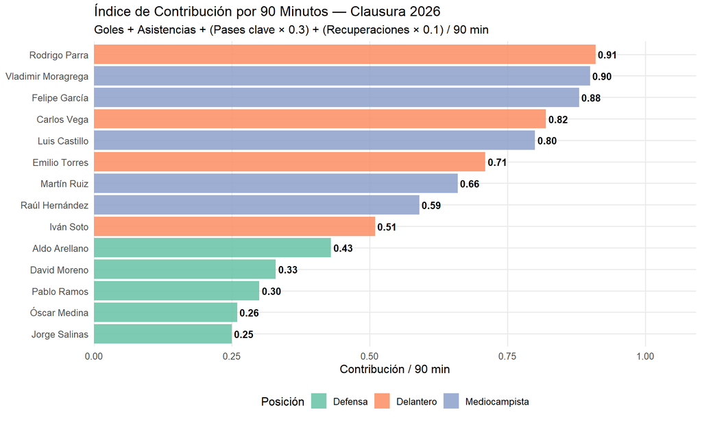

```r
jugadores %>%
  mutate(jugador = fct_reorder(jugador, contribucion_90)) %>%
  ggplot(aes(x = jugador, y = contribucion_90, fill = posicion)) +
  geom_col(alpha = 0.85) +
  geom_text(aes(label = sprintf("%.2f", contribucion_90)),
            hjust = -0.12, size = 3.5, fontface = "bold") +
  coord_flip() +
  scale_fill_brewer(palette = "Set2") +
  scale_y_continuous(expand = expansion(mult = c(0, 0.2))) +
  labs(
    title    = "Índice de Contribución por 90 Minutos — Clausura 2026",
    subtitle = "Goles + Asistencias + (Pases clave × 0.3) + (Recuperaciones × 0.1) / 90 min",
    x = NULL, y = "Contribución / 90 min", fill = "Posición"
  ) +
  theme_minimal(base_size = 12) +
  theme(legend.position = "bottom", panel.grid.minor = element_blank())
```

## 7. Rendimiento Defensivo — Duelos

El porcentaje de duelos ganados es un indicador de intensidad física y posicionamiento defensivo.

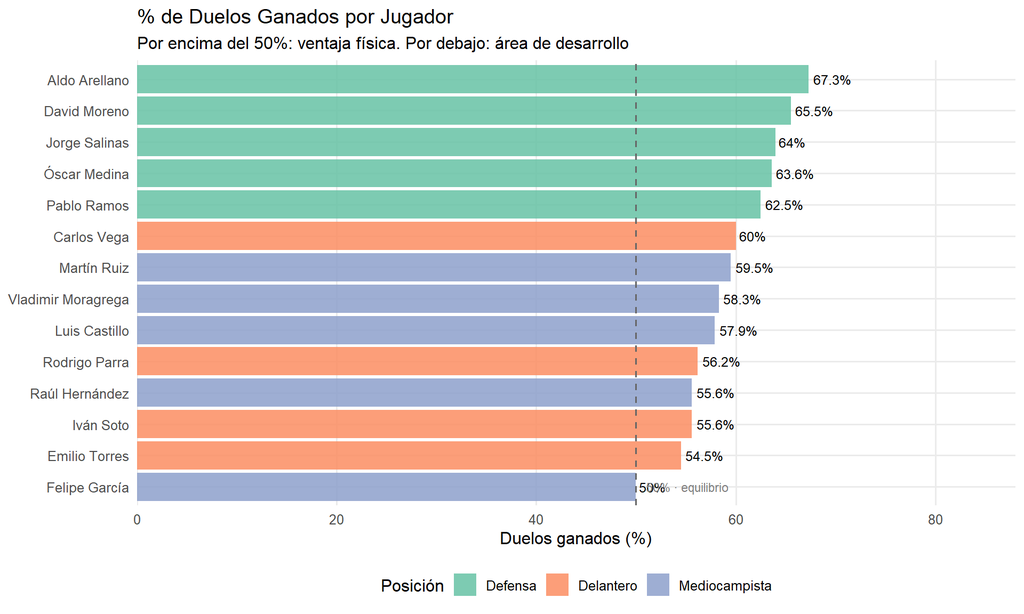

```r
jugadores %>%
  mutate(jugador = fct_reorder(jugador, duelos_pct)) %>%
  ggplot(aes(x = jugador, y = duelos_pct, fill = posicion)) +
  geom_col(alpha = 0.85) +
  geom_hline(yintercept = 50, linetype = "dashed",
             color = "gray40", linewidth = 0.6) +
  geom_text(aes(label = paste0(duelos_pct, "%")),
            hjust = -0.12, size = 3.3) +
  coord_flip() +
  scale_fill_brewer(palette = "Set2") +
  scale_y_continuous(limits = c(0, 80), expand = expansion(mult = c(0, 0.1))) +
  annotate("text", x = 1, y = 51, label = "50% · equilibrio",
           size = 3, color = "gray50", hjust = 0) +
  labs(
    title    = "% de Duelos Ganados por Jugador",
    subtitle = "Por encima del 50%: ventaja física. Por debajo: área de desarrollo",
    x = NULL, y = "Duelos ganados (%)", fill = "Posición"
  ) +
  theme_minimal(base_size = 12) +
  theme(legend.position = "bottom", panel.grid.minor = element_blank())
```

## 8. Perfil por Grupo Posicional

Comparativa de métricas clave agrupadas por línea del equipo.

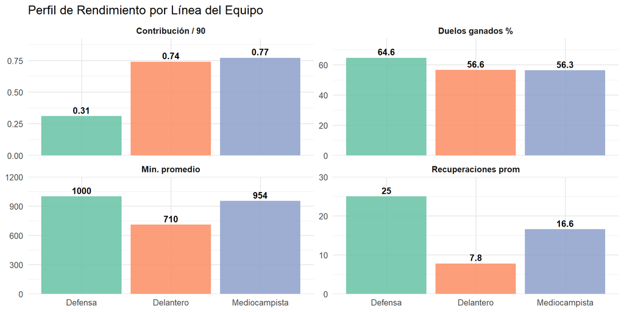

```r
jugadores %>%
  group_by(posicion) %>%
  summarise(
    `Min. promedio`       = round(mean(min)),
    `Contribución / 90`   = round(mean(contribucion_90), 2),
    `Duelos ganados %`    = round(mean(duelos_pct), 1),
    `Recuperaciones prom` = round(mean(recup), 1),
    .groups = "drop"
  ) %>%
  pivot_longer(-posicion, names_to = "metrica", values_to = "valor") %>%
  ggplot(aes(x = posicion, y = valor, fill = posicion)) +
  geom_col(alpha = 0.85) +
  geom_text(aes(label = valor), vjust = -0.4, size = 3.5, fontface = "bold") +
  scale_fill_brewer(palette = "Set2") +
  scale_y_continuous(expand = expansion(mult = c(0, 0.2))) +
  facet_wrap(~metrica, scales = "free_y") +
  labs(
    title = "Perfil de Rendimiento por Línea del Equipo",
    x = NULL, y = NULL, fill = NULL
  ) +
  theme_minimal(base_size = 12) +
  theme(legend.position = "none", strip.text = element_text(face = "bold"))
```

## 9. Gestión de Minutos — Perfil de Desarrollo

Como equipo filial de Chivas, la distribución de minutos en jugadores jóvenes es un indicador clave de desarrollo.

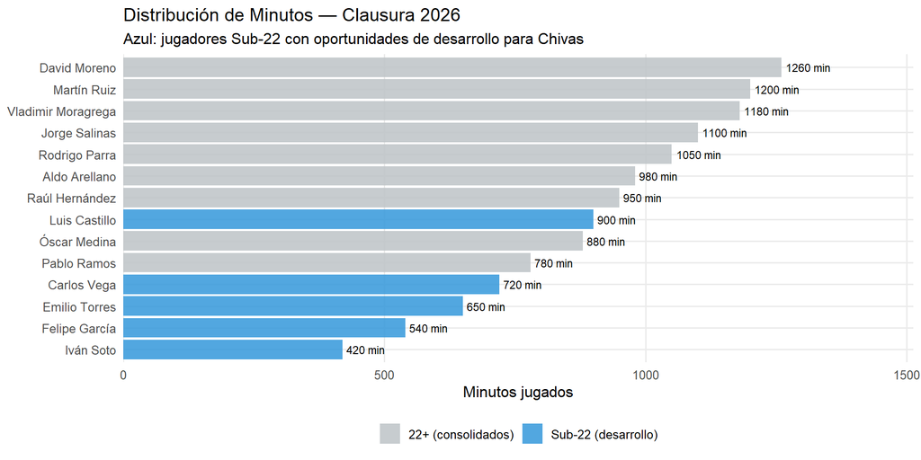

```r
jugadores %>%
  mutate(
    categoria = case_when(edad <= 21 ~ "Sub-22 (desarrollo)", TRUE ~ "22+ (consolidados)"),
    jugador   = fct_reorder(jugador, min)
  ) %>%
  ggplot(aes(x = jugador, y = min, fill = categoria)) +
  geom_col(alpha = 0.85) +
  geom_text(aes(label = paste0(min, " min")), hjust = -0.1, size = 3) +
  coord_flip() +
  scale_fill_manual(values = c("Sub-22 (desarrollo)" = "#3498db",
                                "22+ (consolidados)"  = "#bdc3c7")) +
  scale_y_continuous(expand = expansion(mult = c(0, 0.2))) +
  labs(
    title    = "Distribución de Minutos — Clausura 2026",
    subtitle = "Azul: jugadores Sub-22 con oportunidades de desarrollo para Chivas",
    x = NULL, y = "Minutos jugados", fill = NULL
  ) +
  theme_minimal(base_size = 12) +
  theme(legend.position = "bottom", panel.grid.minor = element_blank())
```

## 10. Forma — Primera vs Segunda Mitad del Torneo

¿El equipo mejoró o cayó conforme avanzó el Clausura 2026? Esta sección compara el rendimiento entre ambas mitades del torneo.

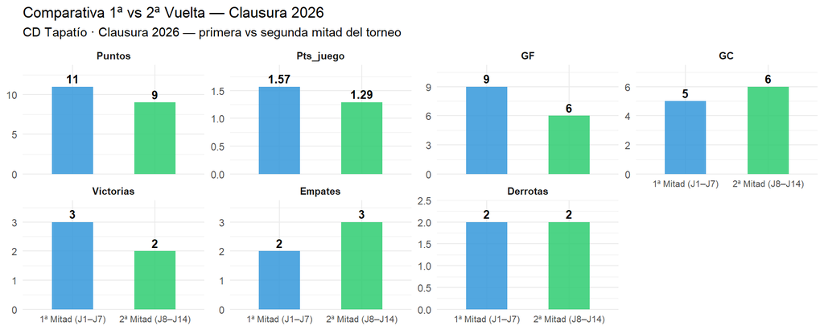

```r
forma <- partidos %>%
  mutate(vuelta = if_else(jornada <= 7, "1ª Mitad (J1–J7)", "2ª Mitad (J8–J14)")) %>%
  group_by(vuelta) %>%
  summarise(
    Puntos     = sum(puntos),
    GF         = sum(gf),
    GC         = sum(gc),
    Victorias  = sum(resultado == "Victoria"),
    Empates    = sum(resultado == "Empate"),
    Derrotas   = sum(resultado == "Derrota"),
    Pts_juego  = round(sum(puntos) / n(), 2),
    .groups    = "drop"
  )

forma %>%
  select(vuelta, Puntos, GF, GC, Victorias, Empates, Derrotas, Pts_juego) %>%
  pivot_longer(-vuelta, names_to = "metrica", values_to = "valor") %>%
  mutate(metrica = factor(metrica, levels = c("Puntos", "Pts_juego", "GF", "GC",
                                               "Victorias", "Empates", "Derrotas"))) %>%
  ggplot(aes(x = vuelta, y = valor, fill = vuelta)) +
  geom_col(alpha = 0.85, width = 0.5) +
  geom_text(aes(label = valor), vjust = -0.4, size = 3.5, fontface = "bold") +
  scale_fill_manual(values = c("1ª Mitad (J1–J7)" = "#3498db",
                                "2ª Mitad (J8–J14)" = "#2ecc71")) +
  scale_y_continuous(expand = expansion(mult = c(0, 0.25))) +
  facet_wrap(~metrica, scales = "free_y", nrow = 2) +
  labs(
    title    = "Comparativa 1ª vs 2ª Vuelta — Clausura 2026",
    subtitle = "CD Tapatío · Clausura 2026 — primera vs segunda mitad del torneo",
    x = NULL, y = NULL, fill = NULL
  ) +
  theme_minimal(base_size = 11) +
  theme(legend.position = "none", strip.text = element_text(face = "bold"),
        axis.text.x = element_text(size = 8))
```

## 11. Comparativa de Liga — Tapatío vs Promedio Expansión

Contexto de rendimiento respecto al promedio estimado de la Liga de Expansión MX.

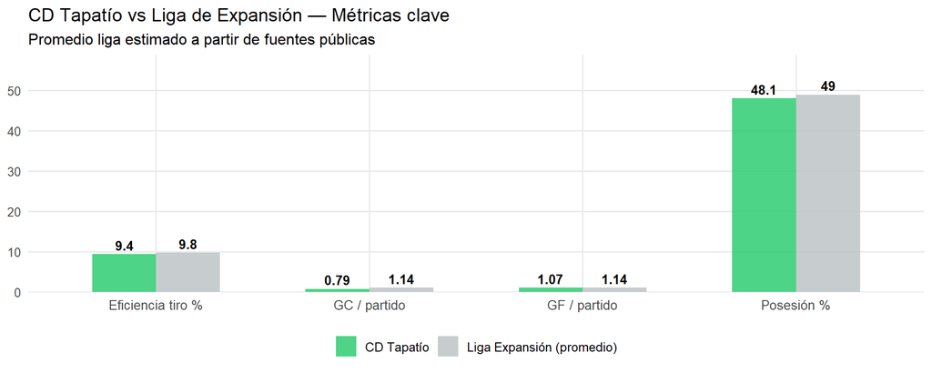

```r
ggplot(liga_prom, aes(x = metrica, y = valor, fill = grupo)) +
  geom_col(position = "dodge", alpha = 0.85, width = 0.6) +
  geom_text(aes(label = valor), position = position_dodge(width = 0.6),
            vjust = -0.4, size = 3.5, fontface = "bold") +
  scale_fill_manual(values = c("Liga Expansión (promedio)" = "#bdc3c7",
                                "CD Tapatío"               = "#2ecc71")) +
  scale_y_continuous(expand = expansion(mult = c(0, 0.2))) +
  labs(
    title    = "CD Tapatío vs Liga de Expansión — Métricas clave",
    subtitle = "Promedio liga estimado a partir de fuentes públicas",
    x = NULL, y = NULL, fill = NULL
  ) +
  theme_minimal(base_size = 12) +
  theme(legend.position = "bottom", panel.grid.minor = element_blank(),
        axis.text.x = element_text(size = 10))
```

## 12. Radar — Rodrigo Parra

Perfil del delantero más destacado del equipo, normalizado respecto al máximo del plantel.

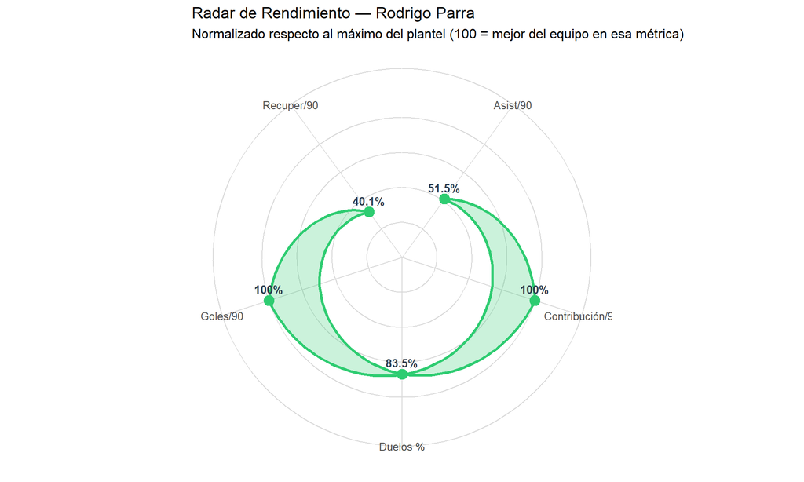

```r
parra <- jugadores %>% filter(jugador == "Rodrigo Parra") %>%
  mutate(recup_90 = round(recup / min_90, 2))

radar_raw <- tibble(
  metrica = c("Goles/90", "Asist/90", "Contribución/90", "Duelos %", "Recuper/90"),
  jugador = c(
    parra$goles_90,
    parra$asist_90,
    parra$contribucion_90,
    parra$duelos_pct,
    parra$recup_90
  ),
  max_equipo = c(
    max(jugadores$goles_90),
    max(jugadores$asist_90),
    max(jugadores$contribucion_90),
    max(jugadores$duelos_pct),
    max(jugadores$recup / jugadores$min_90)
  )
) %>%
  mutate(valor_norm = round(jugador / max_equipo * 100, 1))

radar_plot <- bind_rows(radar_raw, radar_raw[1, ])

ggplot(radar_plot, aes(x = metrica, y = valor_norm, group = 1)) +
  geom_polygon(fill = "#2ecc71", alpha = 0.25, color = "#2ecc71", linewidth = 1.2) +
  geom_point(color = "#2ecc71", size = 4) +
  geom_text(aes(label = paste0(valor_norm, "%")), vjust = -0.8, size = 3.5,
            color = "#2c3e50", fontface = "bold") +
  coord_polar(start = 0) +
  scale_y_continuous(limits = c(0, 120), breaks = c(25, 50, 75, 100)) +
  labs(
    title    = "Radar de Rendimiento — Rodrigo Parra",
    subtitle = "Normalizado respecto al máximo del plantel (100 = mejor del equipo en esa métrica)",
    x = NULL, y = NULL
  ) +
  theme_minimal(base_size = 12) +
  theme(
    axis.text.y  = element_blank(),
    axis.ticks.y = element_blank(),
    panel.grid.major = element_line(color = "gray85", linewidth = 0.4)
  )
```

## 13. Conclusiones y Recomendaciones

### Hallazgos principales

[output not shown]

### Propuestas para el Apertura 2026

**2. Plan de carga y rotación de mediocampistas desde el inicio** Moragrega y Ruiz acumularon más de 1,100 minutos cada uno. Definir desde el inicio del Apertura un esquema de rotación con Felipe García (21 años) evita la acumulación de carga que suele derivar en lesiones o caída de rendimiento en la segunda vuelta.

**3. Emilio Torres como proyecto de titular en Apertura** Con 650 minutos y un índice de contribución competitivo (0.71/90), Torres es el perfil Sub-20 con mayor proyección para Chivas. Darle un rol titular en el Apertura — en lugar de minutos de rotación — acelera su desarrollo y refuerza la misión de cantera del equipo filial.

*Análisis preparado por **Héctor Cárdenas** · Analista de Rendimiento Deportivo* *Email: hcarde78@gmail.com* *Portafolio: reme1982.github.io/football-analytics*

*Metodología: R · tidyverse · ggplot2 · patchwork · ggrepel* *Fuentes: Sofascore · Transfermarkt · tapatiofc.mx · Clausura 2026 (datos estimados con fines demostrativos)*